# A Closer look at the NFL Draft

### By: Siddharaj Vaghela and Sai Pesari

Group Contribution Statement: Both members of the group got together on video calls and worked through the coding and writing.

## Introduction

One of the biggest events of the year in the National Football League (NFL) is the annual draft. In the NFL Draft, teams choose top collegiate players in the nation to join their team. There are 7 rounds in the draft with 32 picks per round. More information on the NFL Draft can be found here. https://operations.nfl.com/the-players/the-nfl-draft/the-rules-of-the-draft/

The wide receiver position is one of the most important, and it's a position that teams want to fill up the most. Within this project, we will be trying to analyze the NFL draft from the wide receiver perspective. We will examine the association between factors such as the combined performance of the wide receiver, their draft position, their rookie year performance, as well as the creation of our own model to predict the round at which the receiver was drawn up and then evaluate the accuracy of our model.

Here is a link to a wikipedia page explaining what the NFL combine is: https://en.wikipedia.org/wiki/NFL_Scouting_Combine

## Curing, Parsing and Handling of Data

We started off by reading in the CSV file that contains player data. The dataset includes entities which are individual players, and attributes include the round a player was drafted, the pick the player was drafted, height, weight, 40 yard dash, shuttle run, and various other combine statistics. The dataset as a whole contains draft data for every player from 2000-2018. We will be focusing on drafted (AKA excluding undrafted) players drafted in the year 2008 to 2017.

```python
import pandas as pd
import numpy as np
import seaborn as sns
import matplotlib.pyplot as plt
from matplotlib.pyplot import figure
import statsmodels.api as sm
from statsmodels.formula.api import ols
```

```python
df = pd.read_csv("combine_data_since_2000_PROCESSED_2018-04-26.csv")
wr_filter = df["Pos"] == "WR"
df_wr = df[wr_filter]
year_filter = df["Year"] >= 2008
df_wr = df_wr[year_filter]
df_wr = df_wr[df_wr['Round'].notna()]
df_wr
```

|  | Player | Pos | Ht | Wt | Forty | Vertical | BenchReps | BroadJump | Cone | Shuttle | Year | Pfr_ID | AV | Team | Round | Pick |
| --- | --- | --- | --- | --- | --- | --- | --- | --- | --- | --- | --- | --- | --- | --- | --- | --- |
| 2609 | Adrian Arrington | WR | 75 | 203 | 4.55 | NaN | NaN | NaN | NaN | NaN | 2008 | ArriAd00 | 1.0 | New Orleans Saints | 7.0 | 237.0 |
| 2610 | Donnie Avery | WR | 71 | 192 | 4.43 | NaN | 16.0 | NaN | NaN | NaN | 2008 | AverDo00 | 9.0 | St. Louis Rams | 2.0 | 33.0 |
| 2621 | Earl Bennett | WR | 71 | 209 | 4.48 | 26.0 | 15.0 | 110.0 | 7.15 | 4.22 | 2008 | BennEa00 | 12.0 | Chicago Bears | 3.0 | 70.0 |
| 2650 | Keenan Burton | WR | 72 | 201 | 4.44 | 38.5 | 10.0 | 125.0 | 6.77 | 4.20 | 2008 | BurtKe00 | 3.0 | St. Louis Rams | 4.0 | 128.0 |
| 2652 | Andre Caldwell | WR | 72 | 204 | 4.35 | 33.0 | NaN | 124.0 | 6.75 | 4.11 | 2008 | CaldAn00 | 8.0 | Cincinnati Bengals | 3.0 | 97.0 |
| ... | ... | ... | ... | ... | ... | ... | ... | ... | ... | ... | ... | ... | ... | ... | ... | ... |
| 5833 | Ryan Switzer | WR | 68 | 181 | 4.51 | 32.0 | 11.0 | 116.0 | 6.77 | 4.00 | 2017 | SwitRy00 | 1.0 | Dallas Cowboys | 4.0 | 133.0 |
| 5838 | Trent Taylor | WR | 68 | 181 | 4.63 | 33.0 | 13.0 | 117.0 | 6.74 | 4.01 | 2017 | TaylTr02 | 3.0 | San Francisco 49ers | 5.0 | 177.0 |
| 5839 | Taywan Taylor | WR | 71 | 203 | 4.50 | 33.5 | 13.0 | 132.0 | 6.57 | 4.21 | 2017 | TaylTa00 | 2.0 | Tennessee Titans | 3.0 | 72.0 |
| 5864 | Dede Westbrook | WR | 72 | 178 | NaN | NaN | NaN | NaN | NaN | NaN | 2017 | WestDe00 | 3.0 | Jacksonville Jaguars | 4.0 | 110.0 |
| 5871 | Mike Williams-04 | WR | 76 | 218 | NaN | 32.5 | 15.0 | 121.0 | NaN | NaN | 2017 | WillMi07 | 1.0 | Los Angeles Chargers | 1.0 | 7.0 |

280 rows × 16 columns

```python
import requests
from bs4 import BeautifulSoup


wr_data = pd.DataFrame()
for year in range(2008,2018):
    headers = {'User-Agent': 'Mozilla/5.0 (Macintosh; Intel Mac OS X 10_15_6) AppleWebKit/537.36 (KHTML, like Gecko) Chrome/85.0.4183.83 Safari/537.36'}
    url = "https://www.pro-football-reference.com/years/" + str(year) + "/receiving.htm"
    r = requests.get(url, headers=headers)
    parse = BeautifulSoup(r.content, "html.parser")
    dat = parse.find("table")
    dat_str = str(dat)
    dat_dat = pd.read_html(dat_str)
    dat_dat = dat_dat[0]
    dat_dat["Season"] = year
    dat_dat = dat_dat.loc[(dat_dat['Pos']=="WR") | (dat_dat['Pos'] == "wr")]
    wr_data = wr_data.append(dat_dat)

wr_data.head()
```

|  | Rk | Player | Tm | Age | Pos | G | GS | Tgt | Rec | Ctch% | Yds | Y/R | TD | 1D | Lng | Y/Tgt | R/G | Y/G | Fmb | Season |
| --- | --- | --- | --- | --- | --- | --- | --- | --- | --- | --- | --- | --- | --- | --- | --- | --- | --- | --- | --- | --- |
| 0 | 1 | Andre Johnson *+ | HOU | 27 | WR | 16 | 16 | 171 | 115 | 67.3% | 1575 | 13.7 | 8 | 79 | 65 | 9.2 | 7.2 | 98.4 | 1 | 2008 |
| 1 | 2 | Wes Welker* | NWE | 27 | WR | 16 | 14 | 149 | 111 | 74.5% | 1165 | 10.5 | 3 | 57 | 64 | 7.8 | 6.9 | 72.8 | 1 | 2008 |
| 2 | 3 | Brandon Marshall* | DEN | 24 | WR | 15 | 15 | 181 | 104 | 57.5% | 1265 | 12.2 | 6 | 67 | 47 | 7.0 | 6.9 | 84.3 | 4 | 2008 |
| 3 | 4 | Larry Fitzgerald*+ | ARI | 25 | WR | 16 | 16 | 154 | 96 | 62.3% | 1431 | 14.9 | 12 | 66 | 78 | 9.3 | 6.0 | 89.4 | 1 | 2008 |
| 5 | 6 | T.J. Houshmandzadeh | CIN | 31 | WR | 15 | 15 | 137 | 92 | 67.2% | 904 | 9.8 | 4 | 51 | 46 | 6.6 | 6.1 | 60.3 | 0 | 2008 |

Now we'll join the tables so we can correlate rookie season stats with draft position.

```python
pd.set_option('display.max_columns', 500)
rookie_stats = pd.merge(wr_data, df_wr, on='Player')
year2_filter = rookie_stats["Season"] == rookie_stats["Year"]
rookie_stats = rookie_stats[year2_filter]
rookie_stats
```

|  | Rk | Player | Tm | Age | Pos_x | G | GS | Tgt | Rec | Ctch% | Yds | Y/R | TD | 1D | Lng | Y/Tgt | R/G | Y/G | Fmb | Season | Pos_y | Ht | Wt | Forty | Vertical | BenchReps | BroadJump | Cone | Shuttle | … |
| --- | --- | --- | --- | --- | --- | --- | --- | --- | --- | --- | --- | --- | --- | --- | --- | --- | --- | --- | --- | --- | --- | --- | --- | --- | --- | --- | --- | --- | --- | --- |
| 0 | 7 | Eddie Royal | DEN | 22 | WR | 15 | 15 | 129 | 91 | 70.5% | 980 | 10.8 | 5 | 43 | 93 | 7.6 | 6.1 | 65.3 | 2 | 2008 | WR | 70 | 184 | 4.39 | 36.0 | 24.0 | 124.0 | 7.07 | 4.34 | … |
| 6 | 35 | DeSean Jackson | PHI | 22 | WR | 16 | 15 | 120 | 62 | 51.7% | 912 | 14.7 | 2 | 43 | 60 | 7.6 | 3.9 | 57.0 | 4 | 2008 | WR | 70 | 169 | 4.35 | NaN | NaN | 120.0 | NaN | NaN | … |
| 13 | 56 | Donnie Avery | STL | 24 | WR | 15 | 12 | 102 | 53 | 52.0% | 674 | 12.7 | 3 | 29 | 69 | 6.6 | 3.5 | 44.9 | 0 | 2008 | WR | 71 | 192 | 4.43 | NaN | 16.0 | NaN | NaN | NaN | … |
| 17 | 39 | Austin Collie | IND | 24 | wr | 16 | 5 | 89 | 60 | 67.4% | 676 | 11.3 | 7 | 37 | 39 | 7.6 | 3.8 | 42.3 | 0 | 2009 | WR | 73 | 200 | 4.53 | 34.0 | 17.0 | 120.0 | 6.78 | 4.24 | … |
| 24 | 46 | Jeremy Maclin | PHI | 21 | WR | 15 | 13 | 91 | 56 | 61.5% | 773 | 13.8 | 4 | 31 | 56 | 8.5 | 3.7 | 51.5 | 0 | 2009 | WR | 72 | 198 | 4.43 | NaN | NaN | NaN | NaN | NaN | … |
| ... | ... | ... | ... | ... | ... | ... | ... | ... | ... | ... | ... | ... | ... | ... | ... | ... | ... | ... | ... | ... | ... | ... | ... | ... | ... | ... | ... | ... | ... | … |
| 358 | 50 | JuJu Smith-Schuster | PIT | 21 | wr | 14 | 7 | 79 | 58 | 73.4% | 917 | 15.8 | 7 | 37 | 97 | 11.6 | 4.1 | 65.5 | 0 | 2017 | WR | 73 | 215 | 4.54 | 32.5 | 15.0 | 120.0 | NaN | NaN | … |
| 361 | 118 | Corey Davis | TEN | 22 | WR | 11 | 9 | 65 | 34 | 52.3% | 375 | 11.0 | 0 | 17 | 37 | 5.8 | 3.1 | 34.1 | 1 | 2017 | WR | 75 | 209 | NaN | NaN | NaN | NaN | NaN | NaN | … |
| 363 | 150 | Kenny Golladay | DET | 24 | wr | 11 | 5 | 48 | 28 | 58.3% | 477 | 17.0 | 3 | 18 | 54 | 9.9 | 2.5 | 43.4 | 0 | 2017 | WR | 76 | 218 | 4.50 | 35.5 | 18.0 | 120.0 | 7.00 | 4.15 | … |
| 365 | 159 | Dede Westbrook | JAX | 24 | wr | 7 | 5 | 51 | 27 | 52.9% | 339 | 12.6 | 1 | 15 | 29 | 6.6 | 3.9 | 48.4 | 1 | 2017 | WR | 72 | 178 | NaN | NaN | NaN | NaN | NaN | NaN | … |
| 368 | 325 | Josh Malone | CIN | 21 | WR | 11 | 7 | 17 | 6 | 35.3% | 63 | 10.5 | 1 | 3 | 25 | 3.7 | 0.5 | 5.7 | 0 | 2017 | WR | 75 | 208 | 4.40 | 30.5 | 10.0 | 121.0 | 7.05 | 4.19 | … |

63 rows × 35 columns

## Exploratory Data Analysis

There are many ways to measure performance for wide receivers. For more information on how performance is measured in the NFL for wide receivers, feel free to click on the following link!

https://www.footballoutsiders.com/stats/nfl/wr/2019

Some of the most common ways of measuring a wide receiver’s success are receiving yards and touchdowns, which is what we will be using to measure a receiver’s production. First, let’s look at the relationship between average receiving yards and the round a receiver was selected. The graph below shows us the average receiving yards in a wide receiver’s rookie year plotted against the round that wide receiver was taken in, aggregated from 2008-2017. As we can see below, there does seem to be a trend. On average, the later the round a wide receiver was taken in, the less yards per game the player averaged in his first season. According to the graph, for every round deeper into the draft, the average yards per game goes down, except for round 5 which seems to be an outlier.

This trend can be attributed to the fact that players that are taken earlier in the draft are perceived to have more skill and potential, which results in more playing time during their rookie season and better performance if their skills hold true to the test. Additionally, late round players may not have the same skill, and sometimes lack the trust of coaches to the point where they do not get very much playing time their first year.

```python
rookie_stats["Pick_Per_Round"] = rookie_stats["Pick"] % 32
rookie_stats = rookie_stats.astype({"Y/G": float, "GS": float, "TD": float})
rookie_stats = rookie_stats.rename(columns={"Y/G": "Yards_Per_Game", "GS": "Games_Started"})
yards_per_round = rookie_stats.groupby("Round").agg(("Yards_Per_Game")).mean()

ypr = pd.DataFrame(yards_per_round)
ypr = ypr.reset_index()
```

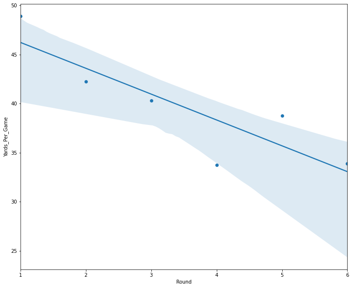

```python
ypr.plot.scatter(x = 'Round', y = 'Yards_Per_Game', figsize=(12, 10))
sns.regplot(x = 'Round', y = 'Yards_Per_Game', data = ypr)
```

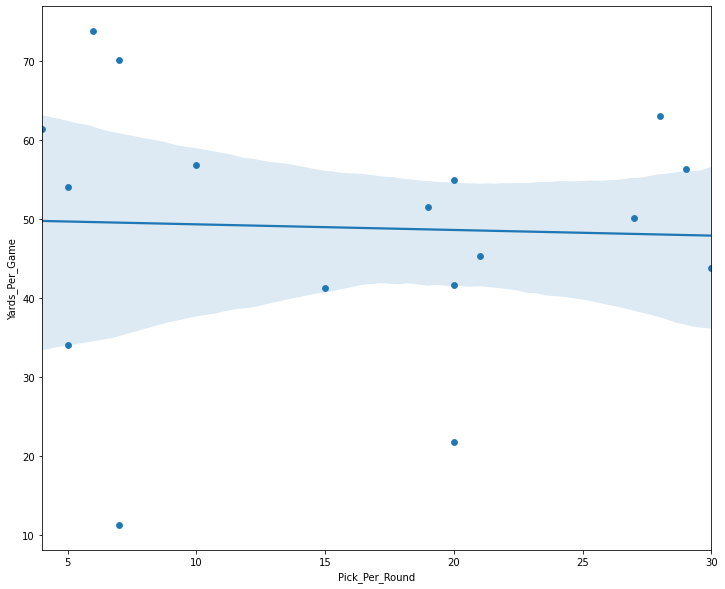

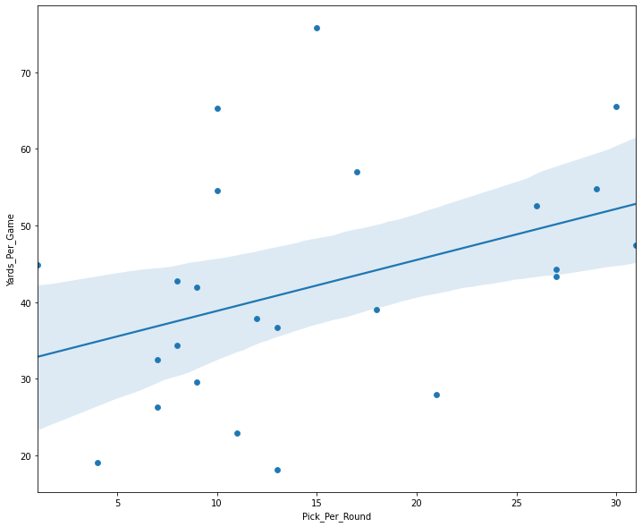

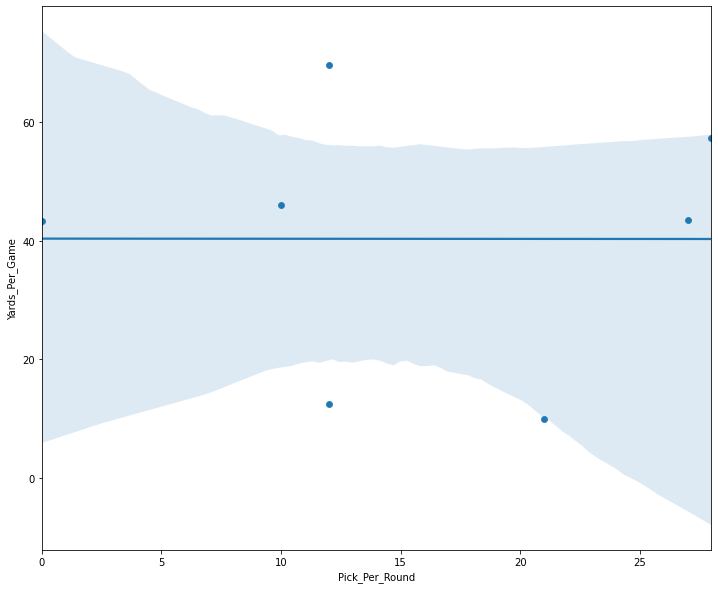

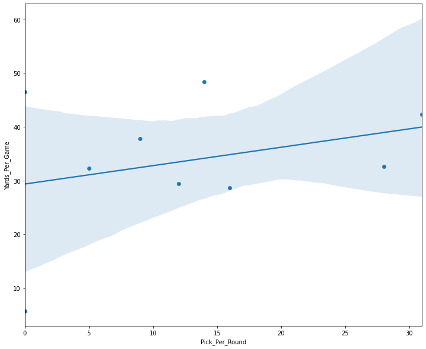

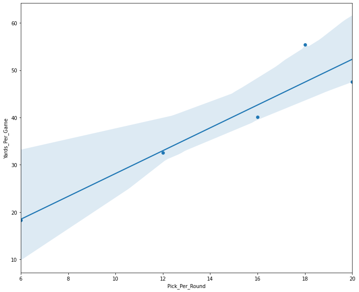

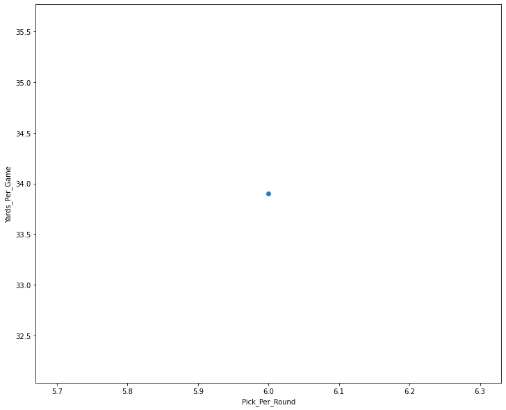

```python
round1_ = pd.DataFrame
round1 = rookie_stats['Round']== 1.0
round1_ = rookie_stats[round1]
round1_.plot.scatter(x = 'Pick_Per_Round', y = 'Yards_Per_Game', figsize=(12, 10))
sns.regplot(x = 'Pick_Per_Round', y = 'Yards_Per_Game', data = round1_)

round2_ = pd.DataFrame
round2 = rookie_stats['Round']== 2.0
round2_ = rookie_stats[round2]
round2_.plot.scatter(x = 'Pick_Per_Round', y = 'Yards_Per_Game', figsize=(12, 10))
sns.regplot(x = 'Pick_Per_Round', y = 'Yards_Per_Game', data = round2_)

round3_ = pd.DataFrame
round3 = rookie_stats['Round']== 3.0
round3_ = rookie_stats[round3]
round3_.plot.scatter(x = 'Pick_Per_Round', y = 'Yards_Per_Game', figsize=(12, 10))
sns.regplot(x = 'Pick_Per_Round', y = 'Yards_Per_Game', data = round3_)

round4_ = pd.DataFrame
round4 = rookie_stats['Round']== 4.0
round4_ = rookie_stats[round4]
round4_.plot.scatter(x = 'Pick_Per_Round', y = 'Yards_Per_Game', figsize=(12, 10))
sns.regplot(x = 'Pick_Per_Round', y = 'Yards_Per_Game', data = round4_)

round5_ = pd.DataFrame
round5 = rookie_stats['Round']== 5.0
round5_ = rookie_stats[round5]
round5_.plot.scatter(x = 'Pick_Per_Round', y = 'Yards_Per_Game', figsize=(12, 10))
sns.regplot(x = 'Pick_Per_Round', y = 'Yards_Per_Game', data = round5_)

round6_ = pd.DataFrame
round6 = rookie_stats['Round']== 6.0
round6_ = rookie_stats[round6]
round6_.plot.scatter(x = 'Pick_Per_Round', y = 'Yards_Per_Game', figsize=(12, 10))
sns.regplot(x = 'Pick_Per_Round', y = 'Yards_Per_Game', data = round6_)
```

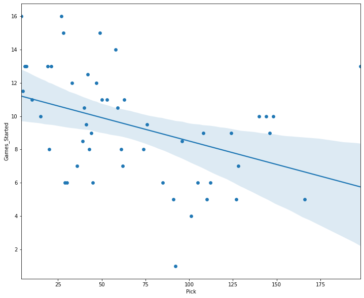

```python
gs_per_round = rookie_stats.groupby("Pick").agg(("Games_Started")).mean()
gpr = pd.DataFrame(gs_per_round)
gpr = gpr.reset_index()

gpr.plot.scatter(x = 'Pick', y = 'Games_Started', figsize=(12, 10))
sns.regplot(x = 'Pick', y = 'Games_Started', data = gpr)
```

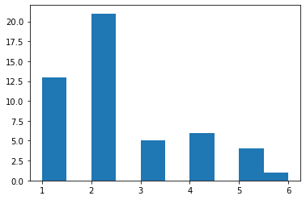

```python
rookie_stats = rookie_stats.sort_values(by='TD', ascending=False)
top_50_td = rookie_stats.head(50)
plt.hist(top_50_td["Round"])
```

# Machine Learning and Hypothesis Testing

Our hypothesis was that there is a relationship between the round that a recevier was draft and how many yards per game they had during their rookie season. To see the relationship between yards per game and round picked in the draft, we're going to conduct an F-test

```python
ypg_lm=ols('Yards_Per_Game~Round', data=rookie_stats).fit() #Specify C for Categorical
print(sm.stats.anova_lm(ypg_lm, typ=2))
```

```
                sum_sq    df         F    PR(>F)
Round      1214.698696   1.0  5.036503  0.028458
Residual  14711.918446  61.0       NaN       NaN
```

After conducting the F-test, we see that the F-test statistic is 5.036503 and the P-value is 0.028458. The P-value is less than the significance value of 0.05, so we can reject the null hypothesis. This shows that yards_per_game and round picked are linearly related, so the round a player got picked has an effect on the yards per game he has produced

Another hypothesis was that there is a relationship between a where a player was drafted and how many touchdowns they scored. To see the relationship between number of touchdowns and round picked in the draft, we're going to conduct an F-test.

```python
td_lm=ols('TD~Round', data=rookie_stats).fit() #Specify C for Categorical
print(sm.stats.anova_lm(td_lm, typ=2))
```

```
              sum_sq    df         F    PR(>F)
Round       9.441440   1.0  1.475706  0.229129
Residual  390.272846  61.0       NaN       NaN
```

After conducting the F-test, we see that the F-test statistic is 1.475706 and the P-value is 0.229129. The P-value is greater than the significance value of 0.05, so we failed to reject the null hypothesis. This shows that we fail to state that the relationship between number of touchdowns and round picked is linear.

In this next part, we will be using combine results to create a regression model to predict the round in which an NFL player will be drafted. First, we create a dataframe of players who have done at least 5 of the major combine drills.

```python
complete_drills = df_wr[df_wr['Forty'].notna()]
complete_drills = complete_drills[complete_drills['Vertical'].notna()]
complete_drills = complete_drills[complete_drills['BroadJump'].notna()]
complete_drills = complete_drills[complete_drills['Ht'].notna()]
complete_drills = complete_drills[complete_drills['Cone'].notna()]
```

Then we'll create a model that will attempt to relate the forty time, vertical, broad jump, height, and cone drill to the round that the player was drafted in.

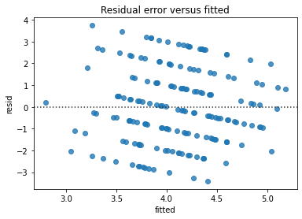

```python
ml_model=ols('Round~Forty+Vertical+BroadJump+Ht+Cone', data=complete_drills).fit()
resid_df = pd.DataFrame()
resid_df["resid"] = ml_model.resid
resid_df["fitted"] = ml_model.fittedvalues

sns.residplot(x = 'fitted', y = 'resid', data = resid_df)
plt.title("Residual error versus fitted")
plt.show()
```

The residual points are centered around 0. This shows us that the normality assumption has not been severely violated and that our errors are within reason.

We can now attempt to find the expected draft position based on the model, which will be plotted alongside the real draft position of each player.

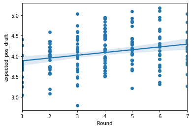

```python
complete_drills["expected_pos_draft"] = ml_model.params[0] + (ml_model.params[1] * complete_drills["Forty"])+ (ml_model.params[2] * complete_drills["Vertical"])+ (ml_model.params[3] * complete_drills["BroadJump"])+ (ml_model.params[4] * complete_drills["Ht"])+ (ml_model.params[5] * complete_drills["Cone"])
complete_drills.plot.scatter(x = 'Round', y = 'expected_pos_draft')
sns.regplot(x = 'Round', y = 'expected_pos_draft', data = complete_drills)
```

Looking at this graph, we can see that our predictive model using regression is not nearly accurate enough. For every actual round a player was drafted in, there is a multitude of different projections that range across the spectrum. The trend line does not at all fit the actual data points, and we can see very clearly that there is no conclusive evidence that our model is accurate. Based on this, we can conclude that in the dataset we used and along with the data tables we scraped, there is no conclusive evidence that combine results are a significant predictor of draft round. Overall, through this project, we were able to go through the data science pipeline and apply it to the NFL Draft. We were able to analyze data in order to make conclusions about various aspects of the draft (specifically with regards to wide receivers), as well as develop our own regression model to attempt predict the rounds in which wide receivers are drafted. After analyzing the results of our model, we were able to come to the conclusion that the NFL draft is extremely hard to predict.

There have been others who have tried to analyze this in the past, we will post their work below.

https://chance.amstat.org/2016/11/draft-and-nfl-performance/

https://seanjtaylor.github.io/learning-the-draft/

Thank you for your time